# Alcohol Beverage Services (ABS)

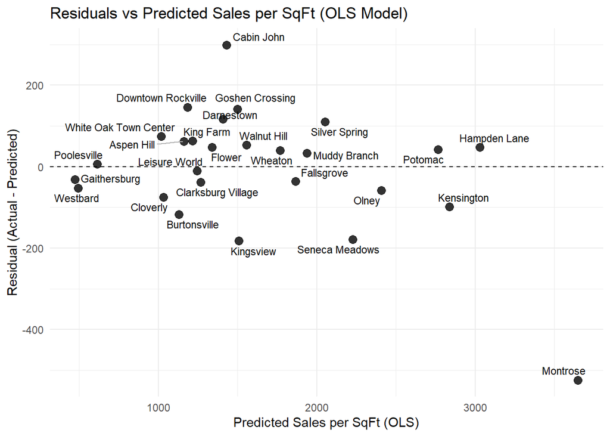

```r
# Residuals vs predicted values
ggplot(model_data,
       aes(x = Pred_Sales_OLS,
           y = Residual_OLS,
           label = STORENAME)) +
  geom_point(size = 3, alpha = 0.8) +
  geom_hline(yintercept = 0, linetype = "dashed") +
  ggrepel::geom_text_repel(
    size          = 3,
    max.overlaps  = 100,
    segment.color = "grey70"
  ) +
  labs(
    title = "Residuals vs Predicted Sales per SqFt (OLS Model)",
    x     = "Predicted Sales per SqFt (OLS)",
    y     = "Residual (Actual - Predicted)"
  ) +
  theme_minimal()
```

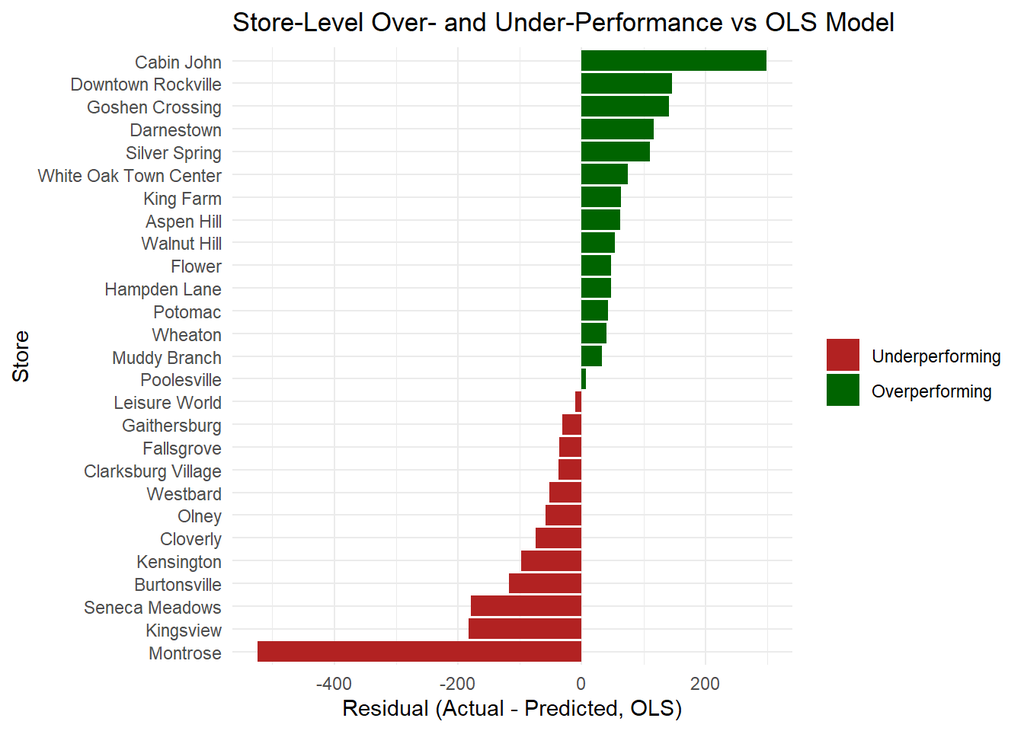

```r
# Store ranking by residual (over/under-performance vs model)
ggplot(model_data,
       aes(x = reorder(STORENAME, Residual_OLS),
           y = Residual_OLS,
           fill = Residual_OLS > 0)) +
  geom_col() +
  coord_flip() +
  scale_fill_manual(
    values = c("TRUE" = "darkgreen",
               "FALSE" = "firebrick"),
    labels = c("FALSE" = "Underperforming",
               "TRUE"  = "Overperforming"),
    name   = ""
  ) +
  labs(
    title = "Store-Level Over- and Under-Performance vs OLS Model",
    x     = "Store",
    y     = "Residual (Actual - Predicted, OLS)"
  ) +
  theme_minimal()
```

#Interpretation: Over- and Under-Performance Relative to the Model

The residual-based ranking isolates systematic deviations between observed store performance and model-predicted performance after controlling for store size, traffic intensity, basket characteristics, category mix, and local demographics. Positive residuals identify stores that generate higher sales per square foot than expected given their structural characteristics, while negative residuals flag stores whose realized performance falls short of modeled expectations.

These residuals should not be interpreted as noise. Instead, they represent operational inefficiencies or advantages that are not fully captured by observable inputs. As such, they provide a defensible basis for prioritizing managerial attention: over-performing stores may reflect best practices worth replicating, while under-performing stores represent candidates for targeted intervention rather than blanket system-wide changes.

# 17. Ridge and LASSO on Store Data (glmnet-style)

This section extends the store-level modeling framework by applying regularized regression methods to assess model stability and predictor relevance in the presence of multicollinearity. Using the same predictor set defined in the previous section, Ridge and LASSO regression models are estimated on a training subset of stores and evaluated on a held-out test set. Both models operate on the logarithmic scale of sales per square foot and are subsequently back-transformed to the original scale for interpretability.

Ridge regression is used to shrink coefficient magnitudes while retaining all predictors, providing insight into how strongly variables contribute when multicollinearity is present. LASSO regression, in contrast, performs variable selection by shrinking some coefficients exactly to zero, thereby identifying a reduced subset of predictors that retain explanatory power. Model performance is evaluated using root mean squared error (RMSE) and mean absolute error (MAE) on the test set to assess out-of-sample predictive behavior.

```r
set.seed(123)

# Train/test split
n <- nrow(model_data)
train_idx <- sample(seq_len(n), size = round(0.8 * n))

store_train <- model_data[train_idx, ]
store_test  <- model_data[-train_idx, ]


# x/y matrices for glmnet (train only)
x_train <- store_train %>%
  dplyr::select(all_of(predictors)) %>%
  as.matrix()

y_train <- store_train$log_SalesPerSqFt

# Test matrices
x_test  <- store_test %>%
  dplyr::select(all_of(predictors)) %>%
  as.matrix()

y_test  <- store_test$log_SalesPerSqFt

# Ridge: alpha = 0
set.seed(123)
cv_ridge <- cv.glmnet(x_train, y_train, alpha = 0)
lambda_ridge <- cv_ridge$lambda.min
lambda_ridge
```

```
## [1] 0.04717665
```

```r
ridge_model <- glmnet(
  x_train, y_train,
  alpha  = 0,
  lambda = lambda_ridge
)

coef(ridge_model)
```

```
## 13 x 1 sparse Matrix of class "dgCMatrix"
##                                     s0
## (Intercept)               6.651349e+00
## SquareFootage             3.284430e-05
## TotalPopulation           8.241549e-07
## Older25Years             -2.807930e-07
## PovertyLevel             -4.145401e-05
## Avg_BasketValue          -4.012647e-03
## AvgItemsPerBasket        -3.176657e-01
## TotalTransactionsPerSqFt  1.518497e-02
## Share_BEER                1.532015e+00
## Share_LIQ                -1.514047e-01
## Share_WINE                2.627269e-01
## Share_Weekday             1.057589e+00
## Share_Weekend            -1.513256e+00
```

```r
# Predict on test stores (on log scale, then back-transform)
pred_log_ridge <- predict(ridge_model, newx = x_test)
pred_Sales_ridge <- exp(pred_log_ridge)

rmse_ridge <- sqrt(mean((store_test$SalesPerSqFt - pred_Sales_ridge)^2))
mae_ridge  <- mean(abs(store_test$SalesPerSqFt - pred_Sales_ridge))

c(RMSE = rmse_ridge, MAE = mae_ridge)
```

```
##     RMSE      MAE
## 483.3029 388.3795
```

```r
# LASSO: alpha = 1
set.seed(123)
cv_lasso <- cv.glmnet(x_train, y_train, alpha = 1)
lambda_lasso <- cv_lasso$lambda.min
lambda_lasso
```

```
## [1] 0.06687169
```

```r
lasso_model <- glmnet(
  x_train, y_train,
  alpha  = 1,
  lambda = lambda_lasso
)

# Coefficients (which predictors survive)
coef(lasso_model)
```

```
## 13 x 1 sparse Matrix of class "dgCMatrix"
##                                  s0
## (Intercept)              6.25328765
## SquareFootage            .
## TotalPopulation          .
## Older25Years             .
## PovertyLevel             .
## Avg_BasketValue          .
## AvgItemsPerBasket        .
## TotalTransactionsPerSqFt 0.01421421
## Share_BEER               .
## Share_LIQ                .
## Share_WINE               .
## Share_Weekday            .
## Share_Weekend            .
```

```r
# Predict on test stores (again transform back from log)
pred_log_lasso  <- predict(lasso_model, newx = x_test)
pred_Sales_lasso <- exp(pred_log_lasso)

rmse_lasso <- sqrt(mean((store_test$SalesPerSqFt - pred_Sales_lasso)^2))
mae_lasso  <- mean(abs(store_test$SalesPerSqFt - pred_Sales_lasso))

c(RMSE = rmse_lasso, MAE = mae_lasso)
```

```
##     RMSE      MAE
## 363.4062 248.7671
```

# 18. Elastic Net – Predictions, Metrics, and Drivers

Elastic Net regression is used to balance the properties of Ridge and LASSO by simultaneously performing coefficient shrinkage and variable selection. Elastic Net predictions are generated for all stores, and residuals are computed to enable direct comparison with the OLS model. In-sample performance metrics for OLS and Elastic Net are compared to assess relative fit, while coefficient estimates are examined to identify robust performance drivers that persist under regularization.

To evaluate model generalizability, a simple train–test validation is conducted at the store level. OLS models are refit on a reduced training sample and evaluated on held-out stores to assess changes in predictive accuracy. Given the limited number of stores, these validation results are interpreted as diagnostic rather than predictive, emphasizing the descriptive purpose of the modeling exercise. Finally, performance metrics across OLS, Elastic Net, Ridge, and LASSO models are summarized and visualized to highlight trade-offs between interpretability, stability, and predictive error.

```r
# Elastic Net predictions and residuals
pred_log_enet <- as.numeric(predict(enet_model, newx = x))

model_data <- model_data %>%
  mutate(
    Pred_log_ENET   = pred_log_enet,
    Pred_Sales_ENET = exp(Pred_log_ENET),
    Residual_ENET   = SalesPerSqFt - Pred_Sales_ENET
  )

# Compare in-sample metrics: OLS vs ENET
rmse_ols  <- sqrt(mean(model_data$Residual_OLS^2,  na.rm = TRUE))
mae_ols   <- mean(abs(model_data$Residual_OLS),    na.rm = TRUE)

rmse_enet <- sqrt(mean(model_data$Residual_ENET^2, na.rm = TRUE))
mae_enet  <- mean(abs(model_data$Residual_ENET),   na.rm = TRUE)

fit_compare <- tibble(
  Model = c("OLS", "Elastic Net"),
  RMSE  = c(rmse_ols, rmse_enet),
  MAE   = c(mae_ols,  mae_enet)
)

fit_compare
```

```
## # A tibble: 2 × 3
##   Model        RMSE   MAE
##   <chr>       <dbl> <dbl>
## 1 OLS          144.  99.5
## 2 Elastic Net  245. 173.
```

```r
# Extract and tidy Elastic Net coefficients
enet_mat <- as.matrix(coef(enet_model))

enet_tidy <- tibble(
  term     = rownames(enet_mat),
  estimate = as.numeric(enet_mat[, 1])
) %>%
  dplyr::filter(term != "(Intercept)", estimate != 0) %>%
  dplyr::mutate(
    effect_index = (exp(estimate) - 1) * 100
  ) %>%
  dplyr::arrange(desc(abs(effect_index)))

enet_tidy
```

```
## # A tibble: 1 × 3
##   term                     estimate effect_index
##   <chr>                       <dbl>        <dbl>
## 1 TotalTransactionsPerSqFt   0.0123         1.24
```

```r
# Compare which variables OLS and ENET use
ols_terms  <- lm_tidy %>% dplyr::pull(term)
enet_terms <- enet_tidy %>% dplyr::pull(term)

drivers_compare <- tibble(
  term = sort(unique(c(ols_terms, enet_terms)))
) %>%
  mutate(
    In_OLS  = term %in% ols_terms,
    In_ENET = term %in% enet_terms
  )

drivers_compare
```

```
## # A tibble: 12 × 3
##    term                     In_OLS In_ENET
##    <chr>                    <lgl>  <lgl>
##  1 Avg_BasketValue          TRUE   FALSE
##  2 AvgItemsPerBasket        TRUE   FALSE
##  3 Older25Years             TRUE   FALSE
##  4 PovertyLevel             TRUE   FALSE
##  5 Share_BEER               TRUE   FALSE
##  6 Share_LIQ                TRUE   FALSE
##  7 Share_Weekday            TRUE   FALSE
##  8 Share_Weekend            TRUE   FALSE
##  9 Share_WINE               TRUE   FALSE
## 10 SquareFootage            TRUE   FALSE
## 11 TotalPopulation          TRUE   FALSE
## 12 TotalTransactionsPerSqFt TRUE   TRUE
```

```r
# 18.1 Simple Out-of-Sample Check (Train/Test)

set.seed(123)  # fix split for reproducibility

# 18 training / 9 test
n_stores   <- nrow(model_data)
train_idx  <- sample(seq_len(n_stores), size = 18)
test_idx   <- setdiff(seq_len(n_stores), train_idx)

train_data <- model_data[train_idx, ]
test_data  <- model_data[test_idx, ]

# Refit OLS on training only
lm_train <- lm(model_formula, data = train_data)

# Predict on held-out test stores
test_data <- test_data %>%
  mutate(
    Pred_log_OLS_test   = predict(lm_train, newdata = test_data),
    Pred_Sales_OLS_test = exp(Pred_log_OLS_test),
    Residual_OLS_test   = SalesPerSqFt - Pred_Sales_OLS_test
  )

# Out-of-sample metrics
rmse_test <- sqrt(mean(test_data$Residual_OLS_test^2, na.rm = TRUE))
mae_test  <- mean(abs(test_data$Residual_OLS_test), na.rm = TRUE)

# Compare in-sample vs test
ols_fit_summary <- tibble(
  Dataset = c("In-sample (all 27 stores)", "Out-of-sample (9 test stores)"),
  RMSE    = c(lm_rmse, rmse_test),
  MAE     = c(lm_mae,  mae_test)
)

ols_fit_summary
```

```
## # A tibble: 2 × 3
##   Dataset                        RMSE   MAE
##   <chr>                         <dbl> <dbl>
## 1 In-sample (all 27 stores)      144.  99.5
## 2 Out-of-sample (9 test stores)  153. 128.
```

```r
cat("\nIn-sample RMSE (OLS):", round(lm_rmse, 1),
    "\nTest RMSE (OLS):",      round(rmse_test, 1), "\n")
```

```
##
## In-sample RMSE (OLS): 144.1
## Test RMSE (OLS): 152.5
```

```r
cat("In-sample MAE (OLS):",   round(lm_mae, 1),
    "\nTest MAE (OLS):",      round(mae_test, 1),  "\n\n")
```

```
## In-sample MAE (OLS): 99.5
## Test MAE (OLS): 127.7
```

```r
if (rmse_test > 1.5 * lm_rmse) {
  message("With only 27 stores, this model is descriptive, not a production forecasting model.")
}

model_compare <- tibble(
  Model = c("OLS (full)", "Elastic Net", "Ridge (test)", "LASSO (test)"),
  RMSE  = c(lm_rmse, rmse_enet, rmse_ridge, rmse_lasso),
  MAE   = c(lm_mae,  mae_enet,  mae_ridge,  mae_lasso)
)
model_compare
```

```
## # A tibble: 4 × 3
##   Model         RMSE   MAE
##   <chr>        <dbl> <dbl>
## 1 OLS (full)    144.  99.5
## 2 Elastic Net   245. 173.
## 3 Ridge (test)  483. 388.
## 4 LASSO (test)  363. 249.
```

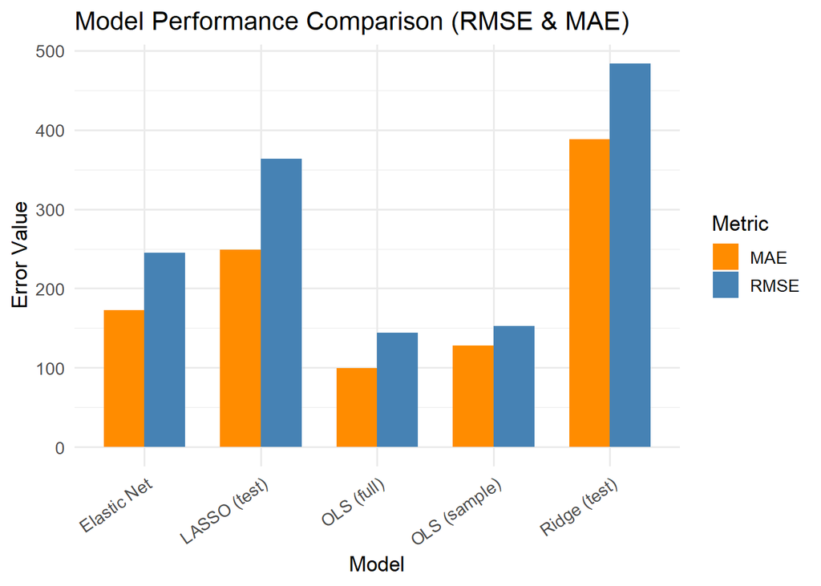

```r
model_df <- tibble(
  Model = c("OLS (full)", "OLS (sample)", "Elastic Net", "Ridge (test)", "LASSO (test)"),
  RMSE  = c(144.11, 152.52, 245.04, 483.30, 363.41),
  MAE   = c(99.46, 127.68, 172.54, 388.38, 248.77)
)

# Convert to long format for plotting
model_long <- model_df %>%
  pivot_longer(cols = c(RMSE, MAE), names_to = "Metric", values_to = "Value")

# Side-by-side bar chart
ggplot(model_long,
       aes(x = Model, y = Value, fill = Metric)) +
  geom_col(position = "dodge", width = 0.7) +
  labs(
    title = "Model Performance Comparison (RMSE & MAE)",
    x = "Model",
    y = "Error Value",
    fill = "Metric"
  ) +
  scale_fill_manual(values = c("RMSE" = "steelblue", "MAE" = "darkorange")) +
  theme_minimal(base_size = 13) +
  theme(
    axis.text.x = element_text(angle = 35, hjust = 1)
  )
```

### Penalized Models (Ridge, LASSO, Elastic Net) – Narrative

To test whether simpler, more robust models outperform OLS in a small-sample setting, Ridge, LASSO, and Elastic Net regressions are estimated using the same predictor set and tuned via cross-validation.

The Elastic Net model (α = 0.5) collapses to an extremely sparse solution, retaining only TotalTransactionsPerSqFt as a non-zero coefficient. This confirms traffic intensity as the single most robust predictor of sales productivity. However, this simplicity comes at a cost: Elastic Net exhibits substantially worse in-sample fit than OLS, indicating that basket metrics and mix variables, while less robust individually, jointly explain meaningful variation.

Train–test splits further show that neither Ridge nor LASSO improves predictive performance relative to OLS. With only 27 stores, the variance reduction gained through regularization does not offset the information loss from coefficient shrinkage.

The correct conclusion is not that regularization “fails,” but that data depth limits its usefulness in this setting. Penalized models confirm the primacy of traffic, but OLS remains the most informative descriptive model given the available data.

# 19. Store-Level Over / Under-Performance vs OLS Model

This section summarizes store-level performance relative to model expectations using residuals from the OLS regression. For each store, actual sales per square foot are compared to model-predicted values, and the resulting residuals indicate the degree of over- or under-performance after controlling for observable characteristics such as store size, traffic, basket behavior, product mix, and demographics.

Positive residuals identify stores that outperform the model’s expectations, while negative residuals indicate under-performance. Ranking stores by residual size provides a concise diagnostic view of which locations deviate most strongly from modeled behavior and highlights candidates for deeper qualitative or operational investigation.

```r
# Table of store-level actual vs predicted vs residual
store_perf_ols <- model_data %>%
  select(
    STORENAME,
    SalesPerSqFt,
    Pred_Sales_OLS,
    Residual_OLS
  ) %>%
  arrange(desc(Residual_OLS))

# Top 5 over-performers
head(store_perf_ols, 5)
```

```
## # A tibble: 5 × 4
##   STORENAME          SalesPerSqFt Pred_Sales_OLS Residual_OLS
##   <chr>                     <dbl>          <dbl>        <dbl>
## 1 Cabin John                1730.          1431.         299.
## 2 Downtown Rockville        1331.          1184.         146.
## 3 Goshen Crossing           1641.          1499.         141.
## 4 Darnestown                1525.          1408.         117.
## 5 Silver Spring             2162.          2051.         111.
```

```r
# Bottom 5 under-performers
tail(store_perf_ols, 5)
```

```
## # A tibble: 5 × 4
##   STORENAME      SalesPerSqFt Pred_Sales_OLS Residual_OLS
##   <chr>                 <dbl>          <dbl>        <dbl>
## 1 Kensington            2738.          2836.        -98.4
## 2 Burtonsville          1011.          1128.       -117.
## 3 Seneca Meadows        2049.          2227.       -179.
## 4 Kingsview             1324.          1506.       -182.
## 5 Montrose              3125.          3649.       -524.
```

# Interpretation: Store-Level Over- and Under-Performance

Store-level residuals are computed as the difference between actual Sales per Square Foot and OLS-predicted Sales per Square Foot. These residuals measure performance relative to modeled expectations, conditional on store size, traffic, basket characteristics, mix, and demographics.

Positive residuals indicate stores that generate more sales per square foot than the model would predict, while negative residuals identify stores that underperform relative to their structural and operational fundamentals.

The residual ranking reveals that several stores substantially outperform expectations, converting their space and traffic into revenue particularly efficiently. Conversely, several stores underperform relative to their modeled potential. Importantly, this is not a ranking of “good” versus “bad” stores. Some underperforming stores still exhibit high absolute Sales per SqFt but appear to leave additional value unrealized given their fundamentals.

Residual analysis therefore serves as a potential lens, not a performance verdict. It highlights where managerial attention may yield the greatest marginal gains.

# 20. Market Basket Analysis (Y24–25)

This section applies Market Basket Analysis to examine item co-purchase patterns during FY24–25 transactions. The analysis focuses on non-refund transactions and constructs one basket per transaction, where each basket represents the set of distinct items purchased together in a single transaction.

To reduce noise and computational complexity, the analysis is restricted to the 200 most frequently purchased items across all transactions. This filtering step ensures that association rules are driven by commonly purchased products rather than rare or idiosyncratic items. Association rules are generated using the Apriori algorithm with conservative support and confidence thresholds, and rule length is limited to two- and three-item combinations to maintain interpretability.

The resulting rules are filtered by lift to identify item combinations that co-occur more frequently than would be expected by chance. These associations are intended to provide descriptive insight into common purchasing patterns and potential cross-selling relationships rather than to serve as prescriptive or causal recommendations.

```r
# Restrict to non-refund Y24–25 transactions
transactions_fs <- transactions %>%
  filter(!IsRefund)

# Top 200 items by frequency across all baskets
item_freq <- transactions_fs %>%
  count(DESCRIPTION, sort = TRUE)

top_n_items <- item_freq %>%
  slice_head(n = 200) %>%
  pull(DESCRIPTION)

# Build one basket per TRANSACTIONID using top-N items only
baskets_mba <- transactions_fs %>%
  filter(DESCRIPTION %in% top_n_items) %>%
  group_by(TRANSACTIONID) %>%
  summarise(
    Items = list(unique(DESCRIPTION)),
    .groups = "drop"
  )

basket_list <- baskets_mba$Items
transactions_mba <- as(basket_list, "transactions")

summary(transactions_mba)
```

```
## transactions as itemMatrix in sparse format with
##  3238237 rows (elements/itemsets/transactions) and
##  200 columns (items) and a density of 0.006168515
##
## most frequent items:
##       TITOS HM VODKA 1 75L FIREBALL CINN WSKY 50ML 10
##                     173297                     134240
## TITO S HANDMADE VODK 750ML           SMIRNOFF 80 50ML
##                      89444                      70644
##         BOWMAN VODKA 375ML                    (Other)
##                      58983                    3468415
##
## element (itemset/transaction) length distribution:
## sizes
##       1       2       3       4       5       6       7       8       9      10
## 2686573  437669   74543   20467    7948    4002    2256    1603    1041     674
##      11      12      13      14      15      16      17      18      19      20
##     447     322     234     148     118      72      38      27      13      11
##      21      22      23      24      25      26      27      30      31
##      11       8       3       1       1       3       1       1       2
##
##    Min. 1st Qu.  Median    Mean 3rd Qu.    Max.
##   1.000   1.000   1.000   1.234   1.000  31.000
##
## includes extended item information - examples:
##                      labels
## 1 1800 SILVER TEQUILA 1 75L
## 2 1800 TEQUILA SILVER 750ML
## 3      99 SCHNPS APPLE 50ML
```

```r
# Apriori rules on reduced item set
rules <- apriori(
  transactions_mba,
  parameter = list(
    supp   = 0.0002,
    conf   = 0.20,
    minlen = 2,
    maxlen = 3,
    target = "rules"
  )
)
```

```
## Apriori
##
## Parameter specification:
##  confidence minval smax arem  aval originalSupport maxtime support minlen
##         0.2    0.1    1 none FALSE            TRUE       5   2e-04      2
##  maxlen target  ext
##       3  rules TRUE
##
## Algorithmic control:
##  filter tree heap memopt load sort verbose
##     0.1 TRUE TRUE  FALSE TRUE    2    TRUE
##
## Absolute minimum support count: 647
##
## set item appearances ...[0 item(s)] done [0.00s].
## set transactions ...[200 item(s), 3238237 transaction(s)] done [0.81s].
## sorting and recoding items ... [200 item(s)] done [0.06s].
## creating transaction tree ... done [5.65s].
## checking subsets of size 1 2 3
```

```
##  done [0.03s].
## writing ... [14 rule(s)] done [0.00s].
## creating S4 object  ... done [0.71s].
```

```r
# Filter rules with modest lift and sort by lift
rules_filtered <- subset(rules, lift > 1.05)
rules_top <- sort(rules_filtered, by = "lift", decreasing = TRUE)

# Top 20 strongest rules
inspect(head(rules_top, 20))
```

```
##      lhs                                 rhs                                  support confidence     coverage     lift count
## [1]  {NEW AMSTERDAM PASSION F 50ML,
##       NEW AMSTERDAM PEACH 50ML}       => {NEW AMSTERDAM APPLE 50ML}      0.0004425247  0.4490755 0.0009854127 89.22647  1433
## [2]  {NEW AMSTERDAM GRAPEFRUIT 50ML,
##       NEW AMSTERDAM PEACH 50ML}       => {NEW AMSTERDAM APPLE 50ML}      0.0002952224  0.4310189 0.0006849406 85.63882   956
## [3]  {NEW AMSTERDAM APPLE 50ML,
##       NEW AMSTERDAM GRAPEFRUIT 50ML}  => {NEW AMSTERDAM PASSION F 50ML}  0.0002661942  0.4434156 0.0006003267 81.53804   862
## [4]  {NEW AMSTERDAM GRAPEFRUIT 50ML,
##       NEW AMSTERDAM PEACH 50ML}       => {NEW AMSTERDAM PASSION F 50ML}  0.0002890462  0.4220018 0.0006849406 77.60033   936
## [5]  {NEW AMSTERDAM GRAPEFRUIT 50ML,
##       NEW AMSTERDAM PASSION F 50ML}   => {NEW AMSTERDAM APPLE 50ML}      0.0002661942  0.3895165 0.0006833966 77.39273   862
## [6]  {NEW AMSTERDAM APPLE 50ML,
##       NEW AMSTERDAM GRAPEFRUIT 50ML}  => {NEW AMSTERDAM PEACH 50ML}      0.0002952224  0.4917695 0.0006003267 74.15098   956
## [7]  {NEW AMSTERDAM APPLE 50ML,
##       NEW AMSTERDAM PASSION F 50ML}   => {NEW AMSTERDAM PEACH 50ML}      0.0004425247  0.4737190 0.0009341503 71.42924  1433
## [8]  {NEW AMSTERDAM APPLE 50ML,
##       NEW AMSTERDAM PEACH 50ML}       => {NEW AMSTERDAM PASSION F 50ML}  0.0004425247  0.3759182 0.0011771838 69.12618  1433
## [9]  {NEW AMSTERDAM GRAPEFRUIT 50ML,
##       NEW AMSTERDAM PASSION F 50ML}   => {NEW AMSTERDAM PEACH 50ML}      0.0002890462  0.4229553 0.0006833966 63.77488   936
## [10] {NEW AMSTERDAM PASSION F 50ML,
##       NEW AMSTERDAM PEACH 50ML}       => {NEW AMSTERDAM GRAPEFRUIT 50ML} 0.0002890462  0.2933250 0.0009854127 56.52221   936
## [11] {NEW AMSTERDAM APPLE 50ML,
##       NEW AMSTERDAM PASSION F 50ML}   => {NEW AMSTERDAM GRAPEFRUIT 50ML} 0.0002661942  0.2849587 0.0009341503 54.91007   862
## [12] {NEW AMSTERDAM APPLE 50ML,
##       NEW AMSTERDAM PEACH 50ML}       => {NEW AMSTERDAM GRAPEFRUIT 50ML} 0.0002952224  0.2507870 0.0011771838 48.32536   956
## [13] {NEW AMSTERDAM APPLE 50ML}       => {NEW AMSTERDAM PEACH 50ML}      0.0011771838  0.2338937 0.0050329855 35.26743  3812
## [14] {L MARCA PRO ROSE 750ML}         => {L MARCA PROSECCO 750ML}        0.0008535509  0.2408085 0.0035445213 14.48868  2764
```

# Interpretation: Market Basket Associations

Market basket analysis is conducted using non-refund transactions, restricting the item universe to the top 200 SKUs by frequency to ensure computational feasibility. Each transaction is treated as a basket of unique item descriptions, and association rules are estimated using the Apriori algorithm with moderate support and confidence thresholds.

The resulting rule set is highly concentrated. The strongest associations occur within narrow product clusters, particularly among New Amsterdam 50ml flavored SKUs, where customers frequently purchase multiple flavors together. A smaller but clear association also exists between closely related prosecco and prosecco-rosé products.

These results indicate that high-lift associations do exist, but they are primarily micro-patterns within specific brands and size formats rather than broad cross-category relationships. At current thresholds, the analysis does not yet yield system-wide merchandising guidance.

To become operationally useful, future market basket analyses would need to be segmented by category, store type, or margin class, and focused on strategic rather than purely high-volume items. As implemented here, the MBA provides insight into localized bundling behavior rather than actionable planogram design.

# 21. Bootstrapping

This section applies bootstrap resampling methods to quantify uncertainty in key performance metrics without relying on strong parametric assumptions. Bootstrapping is particularly appropriate in this context because several metrics of interest, such as basket values and store-level sales efficiency, exhibit skewed distributions and are based on relatively small sample sizes at the store level.

First, bootstrap resampling is used to estimate a confidence interval for the median basket value at the transaction level. The median is selected as a robust measure of central tendency that is less sensitive to extreme values than the mean. To manage computational constraints, a random subsample of baskets is used when the total number of transactions exceeds a predefined threshold, while preserving the underlying distribution.

Second, bootstrapping is applied at the store level to compare mean sales per square foot between contrasting performance quadrants. Specifically, bootstrap distributions are generated for stores classified as “High Spend & High Traffic” and “Low Spend & Low Traffic.” Percentile-based confidence intervals are used to assess whether differences in average performance between these groups are substantively meaningful. These results are intended to support descriptive comparison and uncertainty assessment rather than formal hypothesis testing.

```r
# 21.1 Per-transaction basket metrics

# Build per-transaction basket metrics
basket_metrics <- transactions %>%
  filter(!IsRefund) %>%
  group_by(TRANSACTIONID) %>%
  summarise(
    BasketTotal = sum(NETAMOUNT, na.rm = TRUE),
    BasketItems = n_distinct(ITEMID),
    .groups     = "drop"
  )

basket_values <- basket_metrics %>%
  filter(!is.na(BasketTotal)) %>%
  pull(BasketTotal)

length(basket_values)
```

```
## [1] 6061745
```

```r
# Subsample baskets for memory control
set.seed(123)

max_n <- 50000L
if (length(basket_values) > max_n) {
  basket_sample <- sample(basket_values, size = max_n, replace = FALSE)
} else {
  basket_sample <- basket_values
}

length(basket_sample)
```

```
## [1] 50000
```

```r
# Bootstrap statistic: median basket total
boot_median_fn <- function(data, indices) {
  median(data[indices], na.rm = TRUE)
}

set.seed(123)

boot_median_res <- boot(
  data      = basket_sample,
  statistic = boot_median_fn,
  R         = 1000
)

# Percentile confidence interval for median basket value
ci_lower <- quantile(boot_median_res$t, 0.025, na.rm = TRUE)
ci_upper <- quantile(boot_median_res$t, 0.975, na.rm = TRUE)

ci_lower
```

```
##  2.5%
## 23.99
```

```r
ci_upper
```

```
## 97.5%
## 24.97
```

```r
# 21.2 Bootstrap by quadrant: High vs Low Sales/Traffic -------

# Prepare data for bootstrapping by quadrant
quad_data <- store_quadrant %>%
  select(STORENAME, TotalSalesPerSqFt, Quad_SalesTraffic) %>%
  filter(!is.na(TotalSalesPerSqFt), !is.na(Quad_SalesTraffic))

# Bootstrap function for mean SalesPerSqFt
boot_mean_quadrant <- function(data, indices) {
  d <- data[indices, , drop = FALSE]
  mean(d$TotalSalesPerSqFt, na.rm = TRUE)
}

# Compare High Spend & High Traffic vs Low Spend & Low Traffic
quad_high <- quad_data %>%
  filter(Quad_SalesTraffic == "High Spend & High Traffic")

quad_low <- quad_data %>%
  filter(Quad_SalesTraffic == "Low Spend & Low Traffic")

set.seed(123)

boot_high <- boot(
  data      = quad_high,
  statistic = boot_mean_quadrant,
  R         = 2000
)

boot_low <- boot(
  data      = quad_low,
  statistic = boot_mean_quadrant,
  R         = 2000
)

# Percentile CIs for each quadrant mean
boot_high_ci <- boot.ci(boot_high, type = "perc")
boot_low_ci  <- boot.ci(boot_low,  type = "perc")

boot_high_ci
```

```
## BOOTSTRAP CONFIDENCE INTERVAL CALCULATIONS
## Based on 2000 bootstrap replicates
##
## CALL :
## boot.ci(boot.out = boot_high, type = "perc")
##
## Intervals :
## Level     Percentile
## 95%   (1947, 2512 )
## Calculations and Intervals on Original Scale
```

```r
boot_low_ci
```

```
## BOOTSTRAP CONFIDENCE INTERVAL CALCULATIONS
## Based on 2000 bootstrap replicates
##
## CALL :
## boot.ci(boot.out = boot_low, type = "perc")
##
## Intervals :
## Level     Percentile
## 95%   ( 819, 1177 )
## Calculations and Intervals on Original Scale
```

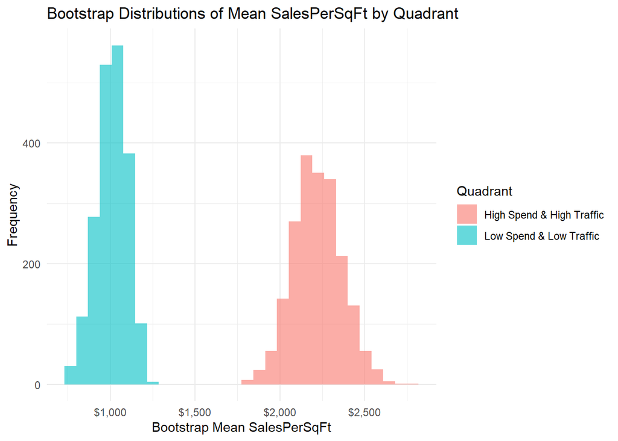

```r
# Combine bootstrap draws for visualization
boot_quad_df <- tibble(
  mean_SalesPerSqFt = c(boot_high$t[, 1], boot_low$t[, 1]),
  Quadrant          = rep(
    c("High Spend & High Traffic",
      "Low Spend & Low Traffic"),
    each = nrow(boot_high$t)
  )
)

# Summary table for export
boot_summary <- tibble(
  Group    = c("High Spend & High Traffic",
               "Low Spend & Low Traffic"),
  Mean     = c(boot_high$t0, boot_low$t0),
  CI_Lower = c(boot_high_ci$percent[4], boot_low_ci$percent[4]),
  CI_Upper = c(boot_high_ci$percent[5], boot_low_ci$percent[5])
)

# Plot bootstrap distributions
ggplot(boot_quad_df,
       aes(x = mean_SalesPerSqFt, fill = Quadrant)) +
  geom_histogram(position = "identity",
                 alpha    = 0.6,
                 bins     = 30) +
  labs(
    title = "Bootstrap Distributions of Mean SalesPerSqFt by Quadrant",
    x     = "Bootstrap Mean SalesPerSqFt",
    y     = "Frequency",
    fill  = "Quadrant"
  ) +
  scale_x_continuous(labels = scales::dollar) +
  theme_minimal()
```

# Interpretation: Bootstrap Confidence Interval for Basket Value

Bootstrapping is used to quantify uncertainty around key performance metrics without relying on parametric assumptions.

First, a non-parametric bootstrap of transaction-level basket totals estimates the median basket value. Using 1,000 resamples of a large random subsample, the 95% confidence interval for the median basket value is approximately $24–$25. This confirms that the typical customer makes a relatively modest purchase, and that higher average basket values observed at the store level are driven by a smaller number of large transactions.

Second, mean Sales per Square Foot is bootstrapped for two structurally distinct store groups: High Spend & High Traffic and Low Spend & Low Traffic. The resulting confidence intervals are well separated, with high-high stores exhibiting roughly double the productivity of low-low stores. This difference is far larger than can be explained by sampling variability alone.

These results confirm that quadrant position reflects economically meaningful differences, not noise. Moving a store across quadrants represents a substantial productivity shift rather than a marginal improvement.

# Interpretation: Performance Differences Across Store Quadrants

# 22. Store Typology & Action Flags

This section synthesizes results from the quadrant analyses and regression modeling into a consolidated store-level typology. Store performance is characterized using normalized efficiency metrics (sales, transactions, and baskets per square foot), quadrant classifications, and residuals from the OLS model. Residual-based performance flags are used to indicate whether a store performs above or below model expectations after controlling for observable characteristics.

Based on these combined indicators, descriptive opportunity flags are assigned to highlight potential performance levers associated with traffic intensity and basket behavior. These flags are not intended as prescriptive recommendations but rather as a structured diagnostic framework to support comparative evaluation across stores. The resulting typology provides a concise summary of each store’s relative position within the system and identifies dimensions along which performance differences are most pronounced.

```r
# 21.1 Combine quadrants and model residuals
store_typology <- store_quadrant %>%
  select(
    STORENAME,
    TotalSalesPerSqFt,
    TotalTransactionsPerSqFt,
    TotalBasketsPerSqFt,
    Quad_SalesTraffic,
    Quad_SalesBaskets
  ) %>%
  left_join(
    model_data %>% select(STORENAME, Residual_OLS),
    by = "STORENAME"
  ) %>%
  mutate(
    PerfFlag = case_when(
      Residual_OLS >=  75 ~ "Strong over-performer",
      Residual_OLS >=  25 ~ "Moderate over-performer",
      Residual_OLS <= -75 ~ "Strong under-performer",
      Residual_OLS <= -25 ~ "Moderate under-performer",
      TRUE                ~ "Near model expectation"
    )
  )
```

```r
# 21.2 Simple opportunity flags (what lever to pull)
store_typology <- store_typology %>%
  mutate(
    Traffic_Opportunity = case_when(
      Quad_SalesTraffic == "High Spend & Low Traffic" ~ "Increase traffic (awareness/location/selection)",
      Quad_SalesTraffic == "Low Spend & Low Traffic"  ~ "Fundamental issue: traffic + value",
      Quad_SalesTraffic == "Low Spend & High Traffic" ~ "Improve conversion / basket value",
      TRUE                                            ~ "Traffic OK"
    ),
    Basket_Opportunity = case_when(
      Quad_SalesBaskets == "High Spend & Low Baskets" ~ "Increase visit frequency / basket count",
      Quad_SalesBaskets == "Low Spend & High Baskets" ~ "Increase basket value (mix, pricing, upsell)",
      Quad_SalesBaskets == "Low Spend & Low Baskets"  ~ "Structural weakness (frequency + value)",
      TRUE                                            ~ "Basket density OK"
    )
  )

# 21.3 Final typology table
store_typology %>%
  arrange(desc(TotalSalesPerSqFt)) %>%
  select(
    STORENAME,
    TotalSalesPerSqFt,
    TotalTransactionsPerSqFt,
    TotalBasketsPerSqFt,
    Quad_SalesTraffic,
    Quad_SalesBaskets,
    PerfFlag,
    Traffic_Opportunity,
    Basket_Opportunity
  )
```

```
## # A tibble: 27 × 9
##    STORENAME      TotalSalesPerSqFt TotalTransactionsPerSqFt TotalBasketsPerSqFt
##    <chr>                      <dbl>                    <dbl>               <dbl>
##  1 Montrose                   3125.                    136.                 78.3
##  2 Hampden Lane               3077.                    118.                 60.8
##  3 Potomac                    2808.                     97.1                51.6
##  4 Kensington                 2738.                    122.                 68.4
##  5 Olney                      2349.                    102.                 61.1
##  6 Silver Spring              2162.                     96.2                59.2
##  7 Seneca Meadows             2049.                     91.3                55.5
##  8 Muddy Branch               1971.                     80.9                45.7
##  9 Fallsgrove                 1829.                     80.7                49.3
## 10 Wheaton                    1809.                     86.1                61.6
## # ℹ 17 more rows
## # ℹ 5 more variables: Quad_SalesTraffic <chr>, Quad_SalesBaskets <chr>,
## #   PerfFlag <chr>, Traffic_Opportunity <chr>, Basket_Opportunity <chr>
```

# Interpretation: Store Typology and Operational Implications

The final store typology integrates three analytical elements: quadrant position based on traffic and basket density, residual-based performance relative to the OLS model, and qualitative opportunity flags derived from these measures.

Quadrants describe a store’s structural position, indicating whether it is fundamentally strong or weak in traffic and sales efficiency. Residuals capture performance relative to potential, indicating whether a store is outperforming or underperforming what its fundamentals would suggest.

These dimensions are combined into performance flags and translated into clear operational guidance. Stores classified as high-priority are those that underperform relative to expectations, regardless of their absolute revenue levels. Several high-priority stores are among the system’s strongest in raw sales terms, but the analysis suggests they could deliver materially higher productivity if specific constraints were addressed.

This typology serves as the bridge from analytics to action. It identifies which stores to focus on first and which lever—traffic, basket value, or both—is most likely to yield gains, providing a structured framework for targeted intervention rather than one-size-fits-all recommendations.

# 23. Priority Store List

This section derives a prioritized list of stores for further review based on residual performance relative to the OLS model. Stores are ranked by residual values, with lower residuals indicating greater under-performance after controlling for observable factors such as store size, traffic intensity, basket behavior, category mix, and demographic context. Performance categories are translated into broad priority levels to distinguish stores that warrant closer analytical attention from those performing near or above expectations.

The resulting priority list is intended as a screening tool rather than a definitive action plan. It highlights locations where performance deviates most strongly from modeled expectations and where additional qualitative investigation may be most informative. This approach supports resource allocation for further analysis while avoiding prescriptive operational conclusions.

```r
priority_stores <- store_typology %>%
  arrange(Residual_OLS) %>%   # worst first
  mutate(
    ActionPriority = case_when(
      PerfFlag %in% c("Strong under-performer", "Moderate under-performer") ~ "High",
      PerfFlag == "Near model expectation"                                  ~ "Medium",
      TRUE                                                                 ~ "Low"
    )
  )

# Top 7 under-performer
priority_stores %>%
  filter(ActionPriority == "High") %>%
  head(7)
```

```
## # A tibble: 7 × 11
##   STORENAME      TotalSalesPerSqFt TotalTransactionsPerSqFt TotalBasketsPerSqFt
##   <chr>                      <dbl>                    <dbl>               <dbl>
## 1 Montrose                   3125.                    136.                 78.3
## 2 Kingsview                  1324.                     62.6                42.0
## 3 Seneca Meadows             2049.                     91.3                55.5
## 4 Burtonsville               1011.                     45.5                28.5
## 5 Kensington                 2738.                    122.                 68.4
## 6 Cloverly                    958.                     41.2                24.2
## 7 Olney                      2349.                    102.                 61.1
## # ℹ 7 more variables: Quad_SalesTraffic <chr>, Quad_SalesBaskets <chr>,
## #   Residual_OLS <dbl>, PerfFlag <chr>, Traffic_Opportunity <chr>,
## #   Basket_Opportunity <chr>, ActionPriority <chr>
```

# Interpretation: Priority Stores for Intervention

The priority list highlights stores with the largest negative residuals relative to model expectations, indicating underperformance beyond what can be explained by observable characteristics. These locations represent the highest potential return for targeted operational interventions and form a natural starting point for deeper qualitative review.

# Limitations and Next Steps

This analysis delivers a coherent view of store-level performance, but it is important to be clear about its limits.

# Key limitations

**Concrete next steps:**

1. Refine the model with more years of data and richer store-level features (competition, hours, staffing) to separate persistent signals from one-year noise.
2. Decompose the quadrants by category (e.g., liquor-only `SalesPerSqFt`) to see whether stores are strong or weak in specific departments.
3. Expand MBA by:
   - Running separate models within large categories.
   - Lowering support thresholds within-store or within-category.
   - Focusing on rules that involve high-margin items.
4. Turn the typology into an action plan, assigning owners and timelines for each high-priority store, with before/after tracking of `SalesPerSqFt`, traffic, and basket metrics.

```r
# EXPORT KEY ANALYTIC TABLES

write_csv(store_final, "ABS_Store_Final_KPIs.csv")
write_csv(model_data, "ABS_Model_Data_For_Regression.csv")
write_csv(store_perf_ols, "ABS_Store_Over_Under_Performance_OLS.csv")
write_csv(store_typology, "ABS_Store_Typology_And_Action_Flags.csv")
write_csv(priority_stores, "ABS_Priority_Store_List.csv")

rules_df <- as.data.frame(as(rules_top, "data.frame"))
write_csv(rules_df, "ABS_Market_Basket_Association_Rules.csv")

write_csv(boot_summary, "ABS_Bootstrap_Quadrant_Comparisons.csv")

# END EXPORT BLOCK
```